# 第二組目的=>分析各個feature組成人數，並找出對於Adaptability最有影響的條件

# The next part is use groupby to find which group in the top three correlated feature have highest performance at adaptivity level.

```python
adapttability_df = pd.read_csv("students_adaptability_level_online_education.csv")
adapttability_df["Adaptivity Level"].replace("Low",  0, inplace = True)
adapttability_df["Adaptivity Level"].replace("Moderate",  1, inplace = True)
adapttability_df["Adaptivity Level"].replace("High",  2, inplace = True)
```

```python
# Use only one feature to groupby.
display(adapttability_df.groupby('Class Duration').mean())
display(adapttability_df.groupby('Institution Type').mean())
display(adapttability_df.groupby('Location').mean())
```

| Class Duration | Adaptivity Level |
| --- | --- |
| 0 | 0.064935 |
| 1-3 | 0.752381 |
| 3-6 | 0.867299 |

| Institution Type | Adaptivity Level |
| --- | --- |
| Government | 0.439791 |
| Non Government | 0.798299 |

| Location | Adaptivity Level |
| --- | --- |
| No | 0.396296 |
| Yes | 0.767914 |

```python
#we can see 3-6 Class Duration, Non Government Institution Type and Yes(which means the student location is in town)
#in Location have highest adaptivity in each feature.
```

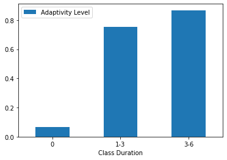

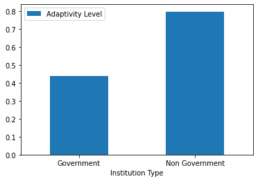

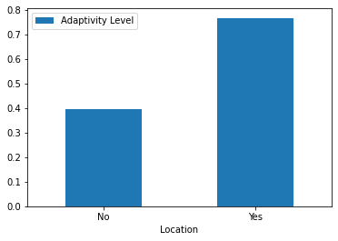

```python
# Use the bar plot to visualize the result.
adapttability_df.groupby('Class Duration').mean().plot(kind="bar", rot=0)
adapttability_df.groupby('Institution Type').mean().plot(kind="bar", rot=0)
adapttability_df.groupby('Location').mean().plot(kind="bar", rot=0)
```

```python
# Use two feature to groupby.
display(adapttability_df.groupby(['Class Duration', 'Institution Type']).mean())
display(adapttability_df.groupby(['Institution Type', 'Location']).mean())
display(adapttability_df.groupby(['Class Duration', 'Location']).mean())
```

| Class Duration | Institution Type | Adaptivity Level |
| --- | --- | --- |
| 0 | Government | 0.055556 |
|  | Non Government | 0.086957 |
| 1-3 | Government | 0.576471 |
|  | Non Government | 0.829060 |
| 3-6 | Government | 0.789474 |
|  | Non Government | 0.875000 |

| Institution Type | Location | Adaptivity Level |
| --- | --- | --- |
| Government | No | 0.259259 |
|  | Yes | 0.572727 |
| Non Government | No | 0.601852 |
|  | Yes | 0.827972 |

| Class Duration | Location | Adaptivity Level |
| --- | --- | --- |
| 0 | No | 0.094118 |
|  | Yes | 0.028986 |
| 1-3 | No | 0.469388 |
|  | Yes | 0.812410 |
| 3-6 | No | 0.789474 |
|  | Yes | 0.884393 |

```python
#we can see the same conclution as above.
#Which is 3-6 Class Duration, Non Government Institution Type and Yes
#(which means the student location is in town) in Location have highest adaptivity in each group.
```

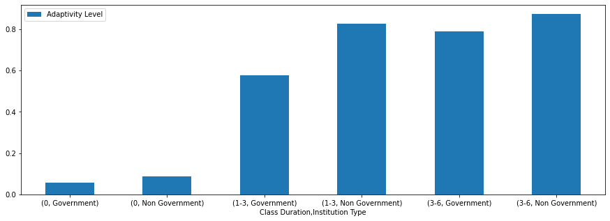

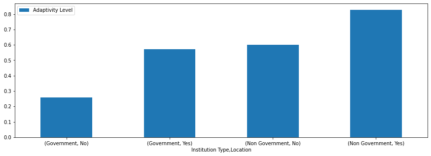

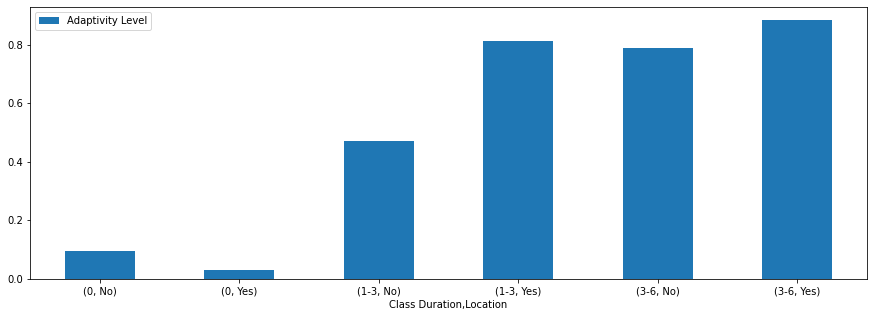

```python
# Use the bar plot to visualize the result.
adapttability_df.groupby(['Class Duration', 'Institution Type']).mean().plot(kind="bar", rot=0, figsize=( 15, 5 ))
adapttability_df.groupby(['Institution Type', 'Location']).mean().plot(kind="bar", rot=0, figsize=( 15, 5 ))
adapttability_df.groupby(['Class Duration', 'Location']).mean().plot(kind="bar", rot=0, figsize=( 15, 5 ))
```

```python
# Use three feature to groupby.
display(adapttability_df.groupby(['Class Duration', 'Institution Type', 'Location']).mean())
```

| Class Duration | Institution Type | Location | Adaptivity Level |
| --- | --- | --- | --- |
| 0 | Government | No | 0.057971 |
|  |  | Yes | 0.051282 |
|  | Non Government | No | 0.250000 |
|  |  | Yes | 0.000000 |
| 1-3 | Government | No | 0.375000 |
|  |  | Yes | 0.682635 |
|  | Non Government | No | 0.610169 |
|  |  | Yes | 0.853612 |
| 3-6 | Government | No | 1.000000 |
|  |  | Yes | 0.714286 |
|  | Non Government | No | 0.757576 |
|  |  | Yes | 0.899371 |

```python
#we can see almost same conclution as above. The group 3-6, Non Government and Yes have high performance at adaptivity.
#But the group 3-6, Government and No have highest performance at adaptivity.
#So we guess number of people in 3-6, Government, No group is less than the other group.
#And the other group lower the average in one or two feature groupby.
#Such as the 3-6, Government, Yes group or 3-6, Non Government, No group.
```

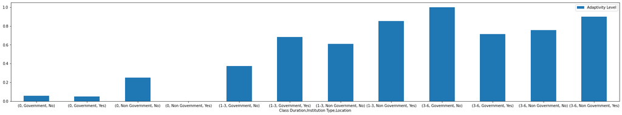

```python
# Use the bar plot to visualize the result.
adapttability_df.groupby(['Class Duration', 'Institution Type', 'Location']).mean().plot(kind="bar", rot=0, figsize=( 30, 5 ))
```

```python
# Use count to confirm our guess.
g1 = (adapttability_df["Class Duration"] == '3-6') & (adapttability_df["Institution Type"] == 'Government') & (adapttability_df["Location"] == 'No')
print(g1.sum())
g2 = (adapttability_df["Class Duration"] == '3-6') & (adapttability_df["Institution Type"] == 'Government') & (adapttability_df["Location"] == 'Yes')
print(g2.sum())
g3 = (adapttability_df["Class Duration"] == '3-6') & (adapttability_df["Institution Type"] == 'Non Government') & (adapttability_df["Location"] == 'No')
print(g3.sum())
g4 = (adapttability_df["Class Duration"] == '3-6') & (adapttability_df["Institution Type"] == 'Non Government') & (adapttability_df["Location"] == 'Yes')
print(g4.sum())
```

```
5
14
33
159
```

```python
# The 3-6, Government, No group really has least number of people.
#So the mean was lowered by the other group.
```

# Conclusion: Through the way we process the data, we can see different sides of the dataset. And the 3-6, Non Government and Yes group generally perform better at Adaptivity Level.

# 用雷達圖的方式呈現每一項特徵對於Adaptability的影響數值大小

```python
from math import pi
plt.style.use('ggplot')
%matplotlib inline
df = pd.read_csv('students_adaptability_level_online_education.csv', encoding = 'big5')
# 將 Adaptivity Level 的低中高分別轉化為分數 1,2,3 分
df['Adaptivity Level'] = df['Adaptivity Level'].map({'Low': 1, 'Moderate': 2, 'High': 3})
df
```

|  | Gender | Age | Education Level | Institution Type | IT Student | Location | Load-shedding | Financial Condition | Internet Type | Network Type | Class Duration | Self Lms | Device | Adaptivity Level |
| --- | --- | --- | --- | --- | --- | --- | --- | --- | --- | --- | --- | --- | --- | --- |
| 0 | Boy | 21-25 | University | Non Government | No | Yes | Low | Mid | Wifi | 4G | 3-6 | No | Tab | 2 |
| 1 | Girl | 21-25 | University | Non Government | No | Yes | High | Mid | Mobile Data | 4G | 1-3 | Yes | Mobile | 2 |
| 2 | Girl | 16-20 | College | Government | No | Yes | Low | Mid | Wifi | 4G | 1-3 | No | Mobile | 2 |
| 3 | Girl | 11-15 | School | Non Government | No | Yes | Low | Mid | Mobile Data | 4G | 1-3 | No | Mobile | 2 |
| 4 | Girl | 16-20 | School | Non Government | No | Yes | Low | Poor | Mobile Data | 3G | 0 | No | Mobile | 1 |
| ... | ... | ... | ... | ... | ... | ... | ... | ... | ... | ... | ... | ... | ... | ... |
| 1200 | Girl | 16-20 | College | Non Government | No | Yes | Low | Mid | Wifi | 4G | 1-3 | No | Mobile | 1 |
| 1201 | Girl | 16-20 | College | Non Government | No | No | High | Mid | Wifi | 4G | 3-6 | No | Mobile | 2 |
| 1202 | Boy | 11-15 | School | Non Government | No | Yes | Low | Mid | Mobile Data | 3G | 1-3 | No | Mobile | 2 |
| 1203 | Girl | 16-20 | College | Non Government | No | No | Low | Mid | Wifi | 4G | 1-3 | No | Mobile | 1 |
| 1204 | Girl | 11-15 | School | Non Government | No | Yes | Low | Poor | Mobile Data | 3G | 1-3 | No | Mobile | 2 |

1205 rows × 14 columns

```python
# 計算每個特徵對於 Adaptivity Level 分數的平均，當作影響數值
gender = df.groupby('Gender').mean().mean()
age = df.groupby('Age').mean().mean()
education_level = df.groupby('Education Level').mean().mean()
institution_type = df.groupby('Institution Type').mean().mean()
it_student = df.groupby('IT Student').mean().mean()
location = df.groupby('Location').mean().mean()
load_shedding = df.groupby('Load-shedding').mean().mean()
financial_condition = df.groupby('Financial Condition').mean().mean()
internet_type = df.groupby('Internet Type').mean().mean()
network_type = df.groupby('Network Type').mean().mean()
class_duration = df.groupby('Class Duration').mean().mean()
self_lms = df.groupby('Self Lms').mean().mean()
device = df.groupby('Device').mean().mean()
```

```python
print('\n')
print("****** The mean score of each feature that affects Adaptivity Level. ******")
print('\n')


print('Gender: ', gender)
print('\nAge: ', age)
print('\nEducation Level: ', education_level)
print('\nInstitution Type: ', institution_type)
print('\nIT Student: ', it_student)
print('\nLocation: ', location)
print('\nLoad-shedding: ', load_shedding)
print('\nFinancial Condition: ', financial_condition)
print('\nInternet Type: ', internet_type)
print('\nNetwork Type: ', network_type)
print('\nClass Duration: ', class_duration)
print('\nSelf Lms: ', self_lms)
print('\nDevice: ', device)
```

```
****** The mean score of each feature that affects Adaptivity Level. ******


Gender:  Adaptivity Level    1.678741
dtype: float64

Age:  Adaptivity Level    1.711542
dtype: float64

Education Level:  Adaptivity Level    1.643445
dtype: float64

Institution Type:  Adaptivity Level    1.619045
dtype: float64

IT Student:  Adaptivity Level    1.728095
dtype: float64

Location:  Adaptivity Level    1.582105
dtype: float64

Load-shedding:  Adaptivity Level    1.637666
dtype: float64

Financial Condition:  Adaptivity Level    1.862314
dtype: float64

Internet Type:  Adaptivity Level    1.693215
dtype: float64

Network Type:  Adaptivity Level    1.500268
dtype: float64

Class Duration:  Adaptivity Level    1.561538
dtype: float64

Self Lms:  Adaptivity Level    1.76772
dtype: float64

Device:  Adaptivity Level    1.857673
dtype: float64
```

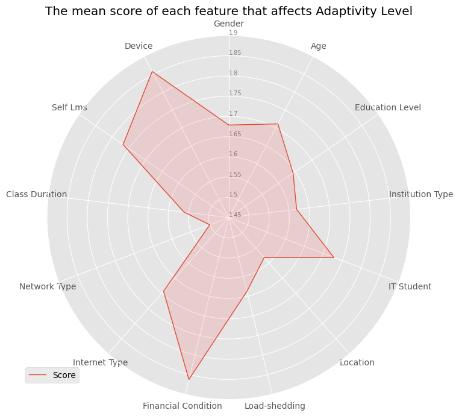

```
 ==> From the radar chart, we can see Financial Condition and Device are two features that greatly affect the Adaptivity Level.
```

```python
df_mean = pd.DataFrame({
    'Name': ['Adaptivity Level'],
    'Gender': [gender],
    'Age': [age],
    'Education Level': [education_level],
    'Institution Type': [institution_type],
    'IT Student': [it_student],
    'Location': [location],
    'Load-shedding': [load_shedding],
    'Financial Condition': [financial_condition],
    'Internet Type': [internet_type],
    'Network Type': [network_type],
    'Class Duration': [class_duration],
    'Self Lms': [self_lms],
    'Device': [device]
})
categories = list(df_mean)[1:]
N = len(categories)

# 角度
angles = [n / float(N) * 2 * pi for n in range(N)]
angles += angles[:1]

# 大小
fig = plt.figure(figsize=(10,8),dpi=100)

# 初始化
ax = plt.subplot(111, polar=True)

# 設定第一處
ax.set_theta_offset(pi / 2)
ax.set_theta_direction(-1) # -1順時鐘，1逆時鐘

# 新增背景資訊
plt.xticks(angles[:-1], categories)
ax.set_rlabel_position(0)
plt.yticks([1.45, 1.5, 1.55, 1.6, 1.65, 1.7, 1.75, 1.8, 1.85, 1.9], ["1.45", "1.5", "1.55", "1.6", "1.65", "1.7", "1.75", "1.8", "1.85", "1.9"], color="grey", size=7)
plt.ylim(1.45, 1.9)

# 新增資料圖
values = df_mean.loc[0].drop('Name').values.flatten().tolist()
values += values[:1]
ax.plot(angles, values, linewidth=1, linestyle='solid', label="Score")
ax.fill(angles, values, 'r', alpha=0.1)

# 新增圖例
plt.title('The mean score of each feature that affects Adaptivity Level')
plt.legend(loc='upper right', bbox_to_anchor=(0.1, 0.1))
# 顯示
plt.show()

print(" ==> From the radar chart, we can see Financial Condition and Device are two features that greatly affect the Adaptivity Level. ")
```

```
                              Adaptivity Level
Financial Condition Device
Mid                 Computer          1.715447
                    Mobile            1.630643
                    Tab               2.000000
Poor                Computer          2.470588
                    Mobile            1.493274
                    Tab               1.000000
Rich                Computer          2.772727
                    Mobile            2.220339
                    Tab               2.500000
```

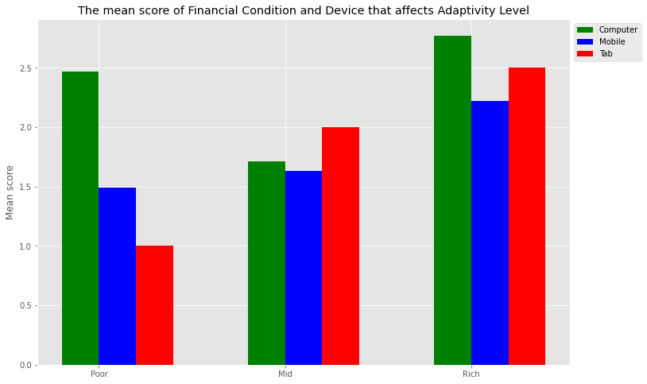

```python
# 看 Financial Condition 和 Device 的關係（長條圖）
financial_condition_device = df.groupby(['Financial Condition', 'Device']).mean()
print(financial_condition_device)
condition = ['Poor', 'Mid', 'Rich']
computer= [2.470588, 1.715447, 2.772727]
mobile = [1.493274, 1.630643, 2.220339]
tab = [1, 2, 2.5]
x = np.arange(len(condition))
width = 0.2
plt.figure(figsize=(12,8))
plt.bar(x, computer, width, color='green', label='Computer')
plt.bar(x + width, mobile, width, color='blue', label='Mobile')
plt.bar(x + width*2, tab, width, color='red', label='Tab')
plt.xticks(x + width/2, condition)
plt.ylabel('Mean score')
plt.title('The mean score of Financial Condition and Device that affects Adaptivity Level')
plt.legend(bbox_to_anchor=(1,1), loc='upper left')
plt.show()
```